# DIGPD GRS: Epigenome-wide asssociation analysis

The manuscript “A Parkinson’s disease genetic risk score associates with blood DNAm on chromosome 17” explores how a genetic risk score (GRS) for Parkinson’s disease (PD) associates with blood DNA methylation in the TERRE study of French agricultural workers, and evaluates GRS associations with DNAm in each sex as well as their sensitivity to non-genetic factors. This was originally spearheaded by Will Casazza and was posted as a pre-print on medRxiv in 2023. The current revision (2024, led by Sam Schaffner) aims to address previous reviewer feedback and prepare the manuscript for re-submission.

In this script, EWAS is conducted to identify DNAm patterns associated with the GRS in the cross-sex and sex-stratified samples in DIGPD. The models are adjusted for batch, cell type, and disease status. Results will be compared with the previous models (adjusted for 10 DNAm PCs).

Last updated July 3, 2024 by Samantha Schaffner

Based on code by Will Casazza

### Loading in and preparing data

```r
# Join together meta data
digpd_pcs <- read.delim("~/SHARE_DECIPHER/pd_grs_ewas_integration/prs_analyses/DIGPD.covariate")
digpd_prs <- read.delim("~/SHARE_DECIPHER/pd_grs_ewas_integration/prs_analyses/digpd_prs.sscore")
DIGPD_IDs_cases <- read.table("/home1/NEURO/SHARE_DECIPHER/processed_DNAm_data/sampleInfo_revised/CORRESPONDANCES_digpd_cases.txt", header=TRUE)
DIGPD_IDs_ctrls <- read.table("/home1/NEURO/SHARE_DECIPHER/processed_DNAm_data/sampleInfo_revised/CORRESPONDANCES_digpd_controls.txt", header=TRUE)
digpd_F <- read.csv("~/SHARE_DECIPHER/processed_DNAm_data/2022/DIGPD_processed_2022/3-digpd_meta_visit1_F_logit_matched.csv")
digpd_M <- read.csv("~/SHARE_DECIPHER/processed_DNAm_data/2022/DIGPD_processed_2022/3-digpd_meta_visit1_M_logit_matched.csv")

digpd_geno <- left_join(digpd_pcs, digpd_prs, by="IID")
colnames(DIGPD_IDs_cases) <- colnames(DIGPD_IDs_ctrls)
IDs <- rbind(DIGPD_IDs_cases, DIGPD_IDs_ctrls)
colnames(IDs)[c(1,3)] <- c("patient","IID")
all(digpd_geno$IID %in% IDs$IID) #FALSE
head(digpd_geno$IID[-which(digpd_geno$IID %in% IDs$IID)])
#[1] "PAL_12770" "PAL_5053"  "PAL_8463"  "PAL_32706" "PAL_2739"  "PAL_3208"
head(IDs$IID[grep("PAL",IDs$IID)])
# "PAL_88_PAL_88"   "PAL_89_PAL_89"   "PAL_220_PAL_220" "PAL_332_PAL_332" "PAL_463_PAL_463" "PAL_555_PAL_555"

#fix IID format
digpd_geno$IID <- unlist(sapply(1:nrow(digpd_geno), function(x){
  if (length(grep("PAL",digpd_geno$IID[x]))>0){
    digpd_geno$IID[x] <- paste(digpd_geno$IID[x], digpd_geno$IID[x], sep="_")
  } else { digpd_geno$IID[x] <- digpd_geno$IID[x] } }))
all(digpd_geno$IID %in% IDs$IID) #TRUE

digpd_geno <- left_join(digpd_geno, IDs[,c(1,3)], by="IID")
digpd_F$reportedSex <- "F"
digpd_M$reportedSex <- "M"
digpd_meta <- rbind(digpd_F, digpd_M)
all(digpd_meta$patient %in% digpd_geno$patient) #TRUE
nrow(digpd_meta <- left_join(digpd_meta, digpd_geno, by="patient")) #222
# cleaning up - remove blank column, duplicate geno PCs
digpd_meta <- digpd_meta[,-c(1,48:57)]
write.csv(digpd_meta, file="~/PD_GRS/digpd_meta_geno_DNAm_PCs.csv", row.names=F)
rm(digpd_pcs, digpd_prs, digpd_geno, digpd_F, digpd_M, DIGPD_IDs_cases, DIGPD_IDs_ctrls, IDs)

# DNAm data (2022, most recent QC'ed, same as npj PD 2024 article)
load("~/SHARE_DECIPHER/processed_DNAm_data/2022/DIGPD_processed_2022/1-DIGPD_RG_filtered.RData")
mvals <- getM(DIGPD_RG_filtered)
rm(DIGPD_RG_filtered)
```

# Association analysis

## EWAS model checks

Prior to looking at results, I’ll assess whether the new EWAS model seems appropriate using three measures:

*1. Variance inflation factor*: The variance inflation factor (VIF) can be used to detect collinearity. Higher VIF values indicate a greater degree of collinearity. Typically VIF < 5 is considered acceptable.

*2. Q-Q plot of nominal p-values*: If the variable of interest does not affect global DNAm, p-values should distribute close to the center line on a normal Q-Q plot, with some deviation at the tail indicating associations detected. The shape of the Q-Q plot can visually indicate model inflation or deflation.

*3. Bias and inflation calculations*: The “bacon” package (van Iterson et al., 2017) was developed to calculate and optionally, correct for, bias and inflation observed in epigenome-wide association studies. It models test statistics using a Bayesian mixture model, and estimates the model parameters: bias (mean) and inflation (standard deviation). The Bayesian mixture model is proposed to more accurately model the quantitative nature and technical/biological influences on epigenomic and transcriptomic data, as opposed to the traditional genomic inflation factor (based on discrete genotypes).

```r
## Preparing data
# match meta data and M-values
mvals <- mvals[,match(digpd_meta$Sample_Name, colnames(mvals))]
all(colnames(mvals)==digpd_meta$Sample_Name) #TRUE

# subset meta data to relevant columns and re-format
meta_sub <- digpd_meta[,c("Sample_Name","SCORE1_AVG","PD","Age","reportedSex","GPC1","GPC2","GPC3","CTP_PC1","CTP_PC2","CTP_PC3","CTP_PC4","CTP_PC5","smoking","pesticides","head_trauma","alcohol","levodopa","agonist","plate","SentrixPosition_A")]
str(meta_sub)
meta_sub$PD <- as.factor(meta_sub$PD)
meta_sub$reportedSex <- as.factor(meta_sub$reportedSex)
meta_sub$smoking <- as.factor(meta_sub$smoking)
meta_sub$pesticides <- as.factor(meta_sub$pesticides)
meta_sub$head_trauma <- as.factor(meta_sub$head_trauma)
meta_sub$alcohol <- as.factor(meta_sub$alcohol)
meta_sub$levodopa <- as.factor(meta_sub$levodopa)
meta_sub$plate <- as.factor(meta_sub$plate)
meta_sub$SentrixPosition_A <- as.factor(meta_sub$SentrixPosition_A)

## Variance inflation factor
# check for one CpG (result is the same as when applied to all CpGs and averaged)
vif(lm(mvals[1,] ~ meta_sub$SCORE1_AVG + meta_sub$Age + meta_sub$reportedSex + meta_sub$GPC1 + meta_sub$GPC2 + meta_sub$GPC3 + meta_sub$CTP_PC1 + meta_sub$CTP_PC2 + meta_sub$CTP_PC3 + meta_sub$CTP_PC4 + meta_sub$CTP_PC5 + meta_sub$plate + meta_sub$SentrixPosition_A + meta_sub$PD))[,3]
#       meta_sub$SCORE1_AVG               meta_sub$Age       meta_sub$reportedSex              meta_sub$GPC1
#                  1.084754                   1.185133                   1.190957                   1.090734
#             meta_sub$GPC2              meta_sub$GPC3           meta_sub$CTP_PC1           meta_sub$CTP_PC2
#                  1.122531                   1.066472                   1.103232                   1.158425
#          meta_sub$CTP_PC3           meta_sub$CTP_PC4           meta_sub$CTP_PC5             meta_sub$plate
#                  1.102377                   1.049864                   1.068049                   1.061057
#meta_sub$SentrixPosition_A                meta_sub$PD
#                  1.090639                   1.468706


## Q-Q plot

#check mvals and replace Inf
min(mvals) #-Inf
min(mvals[mvals>-Inf])
#[1] -16.90111
mvals[mvals==-Inf] <- min(mvals[mvals>-Inf])

pvals <- sapply(1:nrow(mvals), function(x) {
  coef(summary(lm(mvals[x,] ~ meta_sub$SCORE1_AVG + meta_sub$Age + meta_sub$reportedSex + meta_sub$GPC1 + meta_sub$GPC2 + meta_sub$GPC3 + meta_sub$CTP_PC1 + meta_sub$CTP_PC2 + meta_sub$CTP_PC3 + meta_sub$CTP_PC4 + meta_sub$plate + meta_sub$SentrixPosition_A + meta_sub$PD)))[2,4]
   })

qqunif.plot(pvals, title="Model adjusted for PD, batch, and cell type")

## Bias and inflation (based on Z-values)
zvals <- qnorm(pvals)
bacon(zvals)
#Bacon-object containing 1 set(s) of 803734 test-statistics.
#...estimated bias: -0.006.
#...estimated inflation: 0.98.
```

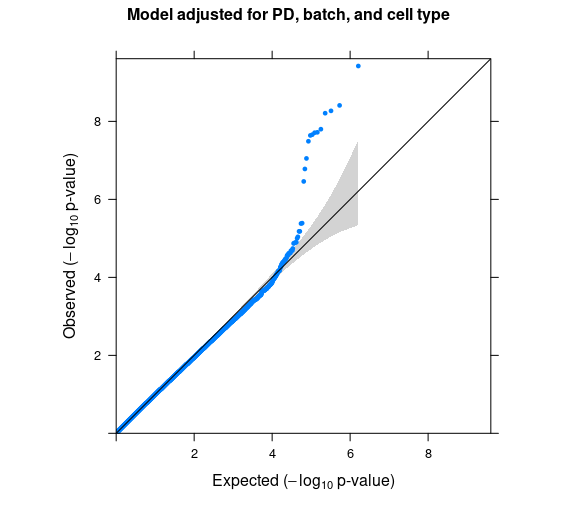

Q-Q plot for updated EWAS model

The majority of p-values follow the expected distribution, while the tail branches off strongly.

VIF calculations indicate low (if any) collinearity, and the bacon results indicate low bias (number should be near zero) and no inflation (number should be near 1).

## Differential methylation analysis

Will used limma on all EPIC probes passing QC, modeling the data with M-values. I’ll continue with this approach and transform results back to beta values later for plotting and interpretation purposes.

First, as Will did, I’ll apply the updated models to (1) the cross-sex sample, (2) males, (3) females, (4) PD cases, and (5) controls. This permits us to detect whether GRS associations with DNAm are dependent on sex and/or disease status.

```r
# set up meta data
na_row <- !apply(meta_sub[, c("SCORE1_AVG", "Age", "reportedSex", "GPC1", "GPC2", "GPC3", "CTP_PC1", "CTP_PC2", "CTP_PC3", "CTP_PC4", "plate", "SentrixPosition_A", "PD")], 1, function(x) any(is.na(x)))
summary(na_row) #no NA's for these covariates
str(meta_sub[,c("SCORE1_AVG", "Age", "reportedSex", "GPC1", "GPC2", "GPC3", "CTP_PC1", "CTP_PC2", "CTP_PC3", "CTP_PC4", "plate", "SentrixPosition_A", "PD")]) #checking format again - good

# limma design matrix and linear model fit
design_prs <- model.matrix(~ 1 + SCORE1_AVG + Age + reportedSex + GPC1 + GPC2 + GPC3 + CTP_PC1 + CTP_PC2 + CTP_PC3 + CTP_PC4 + plate + SentrixPosition_A + PD, data = meta_sub)
prs_fit <- lmFit(mvals, design_prs)
prs_fit <- eBayes(prs_fit)

# Cases only
design_prs_case <- model.matrix(~ 1 + SCORE1_AVG + Age + reportedSex + GPC1 + GPC2 + GPC3 + CTP_PC1 + CTP_PC2 + CTP_PC3 + CTP_PC4 + plate + SentrixPosition_A, data = meta_sub[meta_sub$PD=="1",])
prs_fit_case <- lmFit(mvals[,match(unlist(meta_sub[meta_sub$PD=="1","Sample_Name"]), colnames(mvals))], design_prs_case)
prs_fit_case <- eBayes(prs_fit_case)

# Controls only
design_prs_control <- model.matrix(~ 1 + SCORE1_AVG + Age + reportedSex + GPC1 + GPC2 + GPC3 + CTP_PC1 + CTP_PC2 + CTP_PC3 + CTP_PC4 + plate + SentrixPosition_A, data = meta_sub[meta_sub$PD=="0",])
prs_fit_control <- lmFit(mvals[,match(unlist(meta_sub[meta_sub$PD=="0","Sample_Name"]), colnames(mvals))], design_prs_control)
prs_fit_control <- eBayes(prs_fit_control)

# Males
design_prs_male <- model.matrix(~ 1 + SCORE1_AVG + Age + GPC1 + GPC2 + GPC3 + CTP_PC1 + CTP_PC2 + CTP_PC3 + CTP_PC4 + plate + SentrixPosition_A + PD, data = meta_sub[meta_sub$reportedSex=="M",])
prs_fit_male <- lmFit(mvals[,match(unlist(meta_sub[meta_sub$reportedSex=="M","Sample_Name"]), colnames(mvals))], design_prs_male)
prs_fit_male <- eBayes(prs_fit_male)


# Females
design_prs_female <- model.matrix(~ 1 + SCORE1_AVG + Age + GPC1 + GPC2 + GPC3 + CTP_PC1 + CTP_PC2 + CTP_PC3 + CTP_PC4 + plate + SentrixPosition_A + PD, data = meta_sub[meta_sub$reportedSex=="F",])
prs_fit_female <- lmFit(mvals[,match(unlist(meta_sub[meta_sub$reportedSex=="F","Sample_Name"]), colnames(mvals))], design_prs_female) #Coefficients not estimable: plate6 plate7
prs_fit_female <- eBayes(prs_fit_female)

design_pd <- model.matrix(~ 1 + PD + SCORE1_AVG + Age + GPC1 + GPC2 + GPC3 + CTP_PC1 + CTP_PC2 + CTP_PC3 + CTP_PC4 + plate + SentrixPosition_A + reportedSex, data = meta_sub)
pd_fit <- lmFit(mvals, design_pd)
pd_fit <- eBayes(pd_fit)
pd_res <- limma::topTable(pd_fit, coef = 2, number = Inf, genelist=rownames(mvals))
prs_res <- limma::topTable(prs_fit, coef = 2, number = Inf, genelist=rownames(mvals))
control_res <- limma::topTable(prs_fit_control, coef = 2, number = Inf, genelist=rownames(mvals))
case_res <- limma::topTable(prs_fit_case, coef = 2, number = Inf, genelist=rownames(mvals))
male_res <- limma::topTable(prs_fit_male, coef = 2, number = Inf, genelist=rownames(mvals))
female_res <- limma::topTable(prs_fit_female, coef = 2, number = Inf, genelist=rownames(mvals))

# save everything
# put limma results in separate csv's and together as one RData object for ease later
save(mvals, file="~/PD_GRS/DIGPD_Mvals.RData")
write.csv(meta_sub, file="~/PD_GRS/meta_for_GRS_EWAS_DIGPD.csv", row.names=F)
save(pd_res, prs_res, control_res, case_res, male_res, female_res, file="~/PD_GRS/DIGPD_EWAS_limma_all.RData")
write.csv(pd_res, file="~/PD_GRS/DIGPD_EWAS_PD.csv", row.names=F)
write.csv(prs_res, file="~/PD_GRS/DIGPD_EWAS_GRS_cross_sex.csv", row.names=F)
write.csv(case_res, file="~/PD_GRS/DIGPD_EWAS_GRS_cases.csv", row.names=F)
write.csv(control_res, file="~/PD_GRS/DIGPD_EWAS_GRS_controls.csv", row.names=F)
write.csv(male_res, file="~/PD_GRS/DIGPD_EWAS_GRS_males.csv", row.names=F)
write.csv(female_res, file="~/PD_GRS/DIGPD_EWAS_GRS_females.csv", row.names=F)
```

### Plotting results

For now, I am plotting adjusted delta M-values (model coefficients) to compare with the previous result, and will use the same thresholds reported by Will (delta M > 1.5, padj < 0.05). After, I’ll calculate the delta betas for the same model.

#### Cross-sex GRS EWAS

```r
# annotate topTable
load("~/kobor_shared_coding_resource/EPIC_fdat.RData")
fdat <- fData_EPIC[match(rownames(mvals), fData_EPIC$TargetID),]
all(fdat$TargetID==rownames(mvals))
colnames(prs_res)[1] <- "TargetID"
prs_res <- left_join(prs_res, fdat, by="TargetID")

# logFC: delta M
# AveExpr: average M
colnames(prs_res)[2:3] <- c("delta_M", "avgM")
write.csv(prs_res, file="~/PD_GRS/DIGPD_EWAS_GRS_cross_sex.csv", row.names=F)

# plot with delta M threshold
summary(prs_res$threshold_M <- (prs_res$adj.P.Val <= 0.05 & abs(prs_res$delta_M)>=1.5)) #13
prs_hits <- prs_res[prs_res$threshold_M==TRUE,]
write.csv(prs_hits, file="~/PD_GRS/DIGPD_EWAS_GRS_cross_sex_hits.csv", row.names=F)

max(prs_res[prs_res$threshold_M==TRUE,"P.Value"]) #2.57356e-07
prs_res$DNAm_change <- "NS"
prs_res[prs_res$threshold_M==TRUE & prs_res$delta_M>0,"DNAm_change"] <- "Increase"
prs_res[prs_res$threshold_M==TRUE & prs_res$delta_M<0,"DNAm_change"] <- "Decrease"
summary(as.factor(prs_res$DNAm_change))
#Decrease Increase       NS
#       4        9   803721

# check gene names of hits
View(prs_hits[,c("TargetID","UCSC_REFGENE_NAME")])
prs_hits$UCSC_REFGENE_NAME
# replace repeated gene names
prs_hits$UCSC_REFGENE_NAME <- as.character(prs_hits$UCSC_REFGENE_NAME)
prs_hits$UCSC_REFGENE_NAME <- c("","KANSL1","","ARHGAP27","KANSL1","KANSL1","","MAPT","KANSL1","MAPT","KIAA1267",
                                "MAPT","")
prs_res_hits <- prs_res[match(prs_hits$TargetID, prs_res$TargetID),]
all(prs_res_hits$TargetID==prs_hits$TargetID)
prs_res_hits$UCSC_REFGENE_NAME <- prs_hits$UCSC_REFGENE_NAME
prs_res_other <- prs_res[-(which(prs_res$TargetID %in% prs_hits$TargetID)),]
prs_res_other$UCSC_REFGENE_NAME <- as.character(prs_res_other$UCSC_REFGENE_NAME)
prs_res <- rbind(prs_res_hits, prs_res_other)
write.csv(prs_res, file="~/PD_GRS/DIGPD_EWAS_GRS_cross_sex.csv", row.names=F)
write.csv(prs_res_hits, file="~/PD_GRS/DIGPD_EWAS_GRS_cross_sex_hits.csv", row.names=F)

max(abs(prs_res$delta_M)) #241.1412
max(-log10(prs_res$P.Value)) #9.582231

png("~/PD_GRS/volcano_DIGPD_GRS_cross_sex_Mvals.png", width=200, height=250)
ggplot(prs_res[,c("delta_M","P.Value","DNAm_change","UCSC_REFGENE_NAME")], aes(x=delta_M, y=-log10(P.Value), colour=DNAm_change)) +
  geom_point(size=1.75) +
  labs(legend.position = "none") +
  xlab("Adjusted Delta M") + ylab("-log10 P-Value") + theme_classic() + scale_color_manual(values=c("black","black","gray70")) + geom_hline(yintercept=-log10(2.57356e-07)) + geom_vline(xintercept=-1.5) + geom_vline(xintercept=1.5) +
    geom_label_repel(data = prs_res[prs_res$threshold==TRUE,c("delta_M","P.Value","DNAm_change","UCSC_REFGENE_NAME")],
            aes(label = UCSC_REFGENE_NAME), size = 4, force = 10, max.overlaps=12) + theme(legend.position="none")+ ylim(c(0,10)) + xlim(c(-250,250))
dev.off()

# Compare with TERRE - how many overlap?
terre_prs_hits <- read.csv("~/PD_GRS/EWAS_GRS_cross_sex_hits.csv")
length(prs_res_hits$TargetID[prs_res_hits$TargetID %in% terre_prs_hits$TargetID]) #11
colnames(terre_prs_hits)[2:ncol(terre_prs_hits)] <- paste("terre", colnames(terre_prs_hits)[2:ncol(terre_prs_hits)], sep="_")
overlap <- left_join(terre_prs_hits[,c("TargetID","terre_delta_M","terre_adj.P.Val")], prs_res_hits[,c("TargetID","delta_M","adj.P.Val", "UCSC_REFGENE_NAME")], by="TargetID")
write.csv(overlap, file="~/PD_GRS/EWAS_cross_sex_hits_TERRE_DIGPD.csv", row.names=F)
```

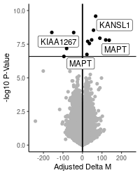

Updated EWAS model - DIGPD

13 probes are significant in the DIGPD cross-sex sample, 11 of which overlapped with TERRE. In other words, 11 of 27 probes from TERRE (41%) replicated in DIGPD.

#### Cross-sex PD status EWAS

```r
# annotate topTable
all(fdat$TargetID==rownames(mvals))
colnames(pd_res)[1] <- "TargetID"
pd_res <- left_join(pd_res, fdat, by="TargetID")

# logFC: delta M
# AveExpr: average M
colnames(pd_res)[2:3] <- c("delta_M", "avgM")

# plot with delta M threshold
summary(pd_res$threshold_M <- (pd_res$adj.P.Val <= 0.05 & abs(pd_res$delta_M)>=1.5)) #none pass threshold
min(pd_res$adj.P.Val) #0.03189665
pd_res$DNAm_change <- "NS"
write.csv(pd_res, file="~/PD_GRS/DIGPD_EWAS_PD.csv", row.names=F)

max(abs(pd_res$delta_M)) #1.577706
max(-log10(pd_res$P.Value)) #6.95248

png("~/PD_GRS/volcano_DIGPD_PD_Mvals.png", width=200, height=250)
ggplot(pd_res[,c("delta_M","P.Value","DNAm_change")], aes(x=delta_M, y=-log10(P.Value), colour=DNAm_change)) +
  geom_point(size=1.75) +
  labs(legend.position = "none") +
  xlab("Adjusted Delta M") + ylab("-log10 P-Value") + theme_classic() + scale_color_manual(values=c("gray70")) + geom_hline(yintercept=-log10(1.7e-06)) + geom_vline(xintercept=-1.5) + geom_vline(xintercept=1.5) + theme(legend.position="none")+ ylim(c(0,10)) + xlim(c(-2,2))
dev.off()
```

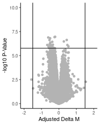

Cross-sex EWAS for PD status - DIGPD

There are no DNAm changes related to PD status in the DIGPD cross-sex sample (effect sizes are very small).

#### Cross-sex GRS EWAS in PD cases

```r
# annotate topTable
all(fdat$TargetID==rownames(mvals))
colnames(case_res)[1] <- "TargetID"
case_res <- left_join(case_res, fdat, by="TargetID")

# logFC: delta M
# AveExpr: average M
colnames(case_res)[2:3] <- c("delta_M", "avgM")

# plot with delta M threshold
summary(case_res$threshold_M <- (case_res$adj.P.Val <= 0.05 & abs(case_res$delta_M)>=1.5)) # 5 significant
case_hits <- case_res[case_res$threshold_M==TRUE,]
write.csv(case_hits, file="~/PD_GRS/DIGPD_EWAS_GRS_cases_hits.csv", row.names=F)

max(case_res[case_res$threshold_M==TRUE,"P.Value"]) #2.883434e-07
case_res$DNAm_change <- "NS"
case_res[case_res$threshold_M==TRUE & case_res$delta_M>0,"DNAm_change"] <- "Increase"
case_res[case_res$threshold_M==TRUE & case_res$delta_M<0,"DNAm_change"] <- "Decrease"
summary(as.factor(case_res$DNAm_change))
#Decrease Increase       NS
#       2        3   803729

# check gene names of hits
View(case_hits[,c("TargetID","UCSC_REFGENE_NAME")])
case_hits$UCSC_REFGENE_NAME
# replace repeated gene names
case_hits$UCSC_REFGENE_NAME <- as.character(case_hits$UCSC_REFGENE_NAME)
case_hits$UCSC_REFGENE_NAME <- c("MAPT","","","","KIAA1267")
case_res_hits <- case_res[match(case_hits$TargetID, case_res$TargetID),]
all(case_res_hits$TargetID==case_hits$TargetID)
case_res_hits$UCSC_REFGENE_NAME <- case_hits$UCSC_REFGENE_NAME
case_res_other <- case_res[-(which(case_res$TargetID %in% case_hits$TargetID)),]
case_res_other$UCSC_REFGENE_NAME <- as.character(case_res_other$UCSC_REFGENE_NAME)
case_res <- rbind(case_res_hits, case_res_other)
write.csv(case_res, file="~/PD_GRS/DIGPD_EWAS_GRS_cases.csv", row.names=F)
write.csv(case_res_hits, file="~/PD_GRS/DIGPD_EWAS_GRS_cases_hits.csv", row.names=F)

max(abs(case_res$delta_M)) #291.7397
max(-log10(case_res$P.Value)) #7.812315

png("~/PD_GRS/volcano_DIGPD_GRS_cases_Mvals.png", width=200, height=250)
ggplot(case_res[,c("delta_M","P.Value","DNAm_change","UCSC_REFGENE_NAME")], aes(x=delta_M, y=-log10(P.Value), colour=DNAm_change)) +
  geom_point(size=1.75) +
  labs(legend.position = "none") +
  xlab("Adjusted Delta M") + ylab("-log10 P-Value") + theme_classic() + scale_color_manual(values=c("black","black","gray70")) + geom_hline(yintercept=-log10(2.883434e-07)) + geom_vline(xintercept=-1.5) + geom_vline(xintercept=1.5) +
    geom_label_repel(data = case_res[case_res$threshold==TRUE,c("delta_M","P.Value","DNAm_change","UCSC_REFGENE_NAME")],
            aes(label = UCSC_REFGENE_NAME), size = 4, force = 10, max.overlaps=12) + theme(legend.position="none")+ ylim(c(0,10)) + xlim(c(-300,300))
dev.off()

# Compare with case-control cross-sex analysis - how many overlap?
length(case_res_hits$TargetID[case_res_hits$TargetID %in% prs_res_hits$TargetID]) #5 - all are in combined sample
```

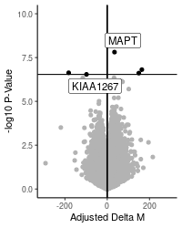

EWAS in PD cases - DIGPD

5 probes from the combined case-control sample are also significant in the case-only sample.

#### Cross-sex GRS EWAS in controls

```r
# annotate topTable
all(fdat$TargetID==rownames(mvals))
colnames(control_res)[1] <- "TargetID"
control_res <- left_join(control_res, fdat, by="TargetID")

# logFC: delta M
# AveExpr: average M
colnames(control_res)[2:3] <- c("delta_M", "avgM")

# plot with delta M threshold
summary(control_res$threshold_M <- (control_res$adj.P.Val <= 0.05 & abs(control_res$delta_M)>=1.5)) #no hits
control_res$DNAm_change <- "NS"
write.csv(control_res, file="~/PD_GRS/DIGPD_EWAS_GRS_controls.csv", row.names=F)

max(abs(control_res$delta_M)) #208.1328
max(-log10(control_res$P.Value)) #5.152369

png("~/PD_GRS/volcano_DIGPD_GRS_controls_Mvals.png", width=200, height=250)
ggplot(control_res[,c("delta_M","P.Value","DNAm_change","UCSC_REFGENE_NAME")], aes(x=delta_M, y=-log10(P.Value), colour=DNAm_change)) +
  geom_point(size=1.75) +
  labs(legend.position = "none") +
  xlab("Adjusted Delta M") + ylab("-log10 P-Value") + theme_classic() + scale_color_manual(values=c("gray70")) + geom_hline(yintercept=-log10(2.883434e-07)) + geom_vline(xintercept=-1.5) + geom_vline(xintercept=1.5) + theme(legend.position="none")+ ylim(c(0,10)) + xlim(c(-250,250))
dev.off()

# Compare effect size with combined sample
# join data together to compare effects and p-values from each analysis
prs_sub <- prs_res_hits[,c("TargetID","delta_M","adj.P.Val")]
colnames(prs_sub) <- c("TargetID", "delta_M_combined", "adj.P.Val.combined")
combine <- left_join(prs_sub, control_res, by="TargetID")
combine <- combine[complete.cases(combine$delta_M_combined),]
max(c(combine$delta_M, combine$delta_M_combined)) #136.7105
min(c(combine$delta_M, combine$delta_M_combined)) #-157.1526

png("~/PD_GRS/DIGPD_EWAS_control_vs_combined_Mvals.png", width=200, height=250)
ggplot(combine, aes(x=delta_M, y=delta_M_combined)) + geom_point() + geom_smooth(method="lm", col="grey") + theme_bw() + xlab("Controls adjusted delta M") + ylab("Combined case-control adjusted delta M") + xlim(c(-200,200)) + ylim(c(-200,200)) + ggtitle("Cross-sex EWAS M-value \ncomparison \n(controls vs. combined)") + stat_cor(label.y=150)
dev.off()

# Compare effect size with cases-only sample
# join data together to compare effects and p-values from each analysis
cases_sub <- case_res_hits[,c("TargetID","delta_M","adj.P.Val")]
colnames(cases_sub) <- c("TargetID", "delta_M_cases", "adj.P.Val.cases")
combine <- left_join(cases_sub, control_res, by="TargetID")
combine <- combine[complete.cases(combine$delta_M_cases),]
max(c(combine$delta_M, combine$delta_M_cases)) #163.7125
min(c(combine$delta_M, combine$delta_M_cases)) #-182.4391

png("~/PD_GRS/DIGPD_EWAS_control_vs_case_Mvals.png", width=200, height=250)
ggplot(combine, aes(x=delta_M, y=delta_M_cases)) + geom_point() + geom_smooth(method="lm", col="grey") + theme_bw() + xlab("Controls adjusted delta M") + ylab("Cases adjusted delta M") + xlim(c(-200,200)) + ylim(c(-200,200)) + ggtitle("Disease-stratified EWAS \nM-value comparison \n(controls vs. cases)") + stat_cor(label.y=150)
dev.off()
```

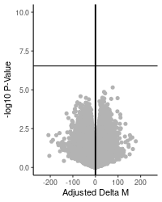

EWAS in controls - DIGPD

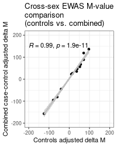

Delta M values are smaller in controls than the combined sample.

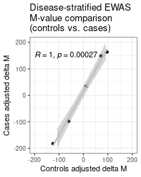

Delta M values are smaller in controls than in PD cases.

#### Females GRS EWAS

```r
# annotate topTable
colnames(female_res)[1] <- "TargetID"
female_res <- left_join(female_res, fdat, by="TargetID")

# logFC: delta M
# AveExpr: average M
colnames(female_res)[2:3] <- c("delta_M", "avgM")
write.csv(female_res, file="~/PD_GRS/DIGPD_EWAS_GRS_females.csv", row.names=F)

# plot with delta M threshold
summary(female_res$threshold_M <- (female_res$adj.P.Val <= 0.05 & abs(female_res$delta_M)>=1.5)) #no hits
min(female_res$adj.P.Val) #0.2994668
female_res$DNAm_change <- "NS"
write.csv(female_res, file="~/PD_GRS/DIGPD_EWAS_GRS_females.csv", row.names=F)

max(abs(female_res$delta_M)) #245.9942
max(-log10(female_res$P.Value)) #5.95423

png("~/PD_GRS/volcano_DIGPD_GRS_females_Mvals.png", width=200, height=250)
ggplot(female_res[,c("delta_M","P.Value","DNAm_change")], aes(x=delta_M, y=-log10(P.Value), colour=DNAm_change)) +
  geom_point(size=1.75) +
  labs(legend.position = "none") +
  xlab("Adjusted Delta M") + ylab("-log10 P-Value") + theme_classic() + scale_color_manual(values=c("gray70")) + geom_hline(yintercept=-log10(2.883434e-07)) + geom_vline(xintercept=-1.5) + geom_vline(xintercept=1.5) + theme(legend.position="none")+ ylim(c(0,10)) + xlim(c(-250,250))
dev.off()
```

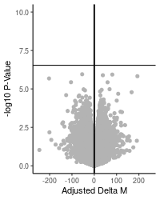

Updated female EWAS model - DIGPD

Nothing reaches statistical significance for females when batch, cell type, and PD status are adjusted for.

#### Males GRS EWAS

```r
# annotate topTable
colnames(male_res)[1] <- "TargetID"
male_res <- left_join(male_res, fdat, by="TargetID")

# logFC: delta M
# AveExpr: average M
colnames(male_res)[2:3] <- c("delta_M", "avgM")

# plot with delta M threshold
summary(male_res$threshold_M <- (male_res$adj.P.Val <= 0.05 & abs(male_res$delta_M)>=1.5)) #no hits
min(male_res$adj.P.Val) #0.9971363
min(male_res$P.Value) #4.77126e-06
male_res$DNAm_change <- "NS"
write.csv(male_res, file="~/PD_GRS/DIGPD_EWAS_GRS_males.csv", row.names=F)

max(abs(male_res$delta_M)) #289.8707
max(-log10(male_res$P.Value)) #5.321367

png("~/PD_GRS/volcano_DIGPD_GRS_males_Mvals.png", width=200, height=250)
ggplot(male_res[,c("delta_M","P.Value","DNAm_change")], aes(x=delta_M, y=-log10(P.Value), colour=DNAm_change)) +
  geom_point(size=1.75) +
  labs(legend.position = "none") +
  xlab("Adjusted Delta M") + ylab("-log10 P-Value") + theme_classic() + scale_color_manual(values=c("gray70")) + geom_hline(yintercept=-log10(2.883434e-07)) + geom_vline(xintercept=-1.5) + geom_vline(xintercept=1.5) + theme(legend.position="none")+ ylim(c(0,10)) + xlim(c(-300,300))
dev.off()
```

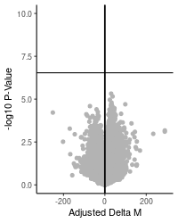

Updated male EWAS model - DIGPD

Nothing reaches statistical significance for males when batch, cell type, and PD status are adjusted for.